# Project Foundations for Data Science: FoodHub Data Analysis

**Marks: 60**

### Context

The number of restaurants in New York is increasing day by day. Lots of students and busy professionals rely on those restaurants due to their hectic lifestyles. Online food delivery service is a great option for them. It provides them with good food from their favorite restaurants. A food aggregator company FoodHub offers access to multiple restaurants through a single smartphone app.

The app allows the restaurants to receive a direct online order from a customer. The app assigns a delivery person from the company to pick up the order after it is confirmed by the restaurant. The delivery person then uses the map to reach the restaurant and waits for the food package. Once the food package is handed over to the delivery person, he/she confirms the pick-up in the app and travels to the customer's location to deliver the food. The delivery person confirms the drop-off in the app after delivering the food package to the customer. The customer can rate the order in the app. The food aggregator earns money by collecting a fixed margin of the delivery order from the restaurants.

### Objective

The food aggregator company has stored the data of the different orders made by the registered customers in their online portal. They want to analyze the data to get a fair idea about the demand of different restaurants which will help them in enhancing their customer experience. Suppose you are hired as a Data Scientist in this company and the Data Science team has shared some of the key questions that need to be answered. Perform the data analysis to find answers to these questions that will help the company to improve the business.

### Data Description

The data contains the different data related to a food order. The detailed data dictionary is given below.

### Data Dictionary

- order_id: Unique ID of the order
- customer_id: ID of the customer who ordered the food
- restaurant_name: Name of the restaurant
- cuisine_type: Cuisine ordered by the customer
- cost: Cost of the order
- day_of_the_week: Indicates whether the order is placed on a weekday or weekend (The weekday is from Monday to Friday and the weekend is Saturday and Sunday)
- rating: Rating given by the customer out of 5
- food_preparation_time: Time (in minutes) taken by the restaurant to prepare the food. This is calculated by taking the difference between the timestamps of the restaurant's order confirmation and the delivery person's pick-up confirmation.
- delivery_time: Time (in minutes) taken by the delivery person to deliver the food package. This is calculated by taking the difference between the timestamps of the delivery person's pick-up confirmation and drop-off information

### Let us start by importing the required libraries

```python
# import libraries for data manipulation
import numpy as np
import pandas as pd

# import libraries for data visualization
import matplotlib.pyplot as plt
import seaborn as sns
```

```python
from google.colab import drive
drive.mount('/content/drive')
```

### Understanding the structure of the data

```python
# read the data
df = pd.read_csv('/content/drive/MyDrive/MIT/Foundations for Data Science/Projects/FoodHub/foodhub_order.csv')
# returns the first 5 rows
df.head()
```

|  | order_id | customer_id | restaurant_name | cuisine_type | cost_of_the_order | day_of_the_week | rating | food_preparation_time | delivery_time |
| --- | --- | --- | --- | --- | --- | --- | --- | --- | --- |
| 0 | 1477147 | 337525 | Hangawi | Korean | 30.75 | Weekend | Not given | 25 | 20 |
| 1 | 1477685 | 358141 | Blue Ribbon Sushi Izakaya | Japanese | 12.08 | Weekend | Not given | 25 | 23 |
| 2 | 1477070 | 66393 | Cafe Habana | Mexican | 12.23 | Weekday | 5 | 23 | 28 |
| 3 | 1477334 | 106968 | Blue Ribbon Fried Chicken | American | 29.20 | Weekend | 3 | 25 | 15 |
| 4 | 1478249 | 76942 | Dirty Bird to Go | American | 11.59 | Weekday | 4 | 25 | 24 |

#### Observations:

The DataFrame has 9 columns as mentioned in the Data Dictionary. Data in each row corresponds to the order placed by a customer.

### **Question 1:** How many rows and columns are present in the data? [0.5 mark]

```python
df.shape # getting shape of the dataframe
# According to the shape of the dataframe there are 1898 rows and 9 columns
print(f"Rows: {df.shape[0]} Columns: {df.shape[1]}")
```

[output not shown]

#### Observations: 1898 rows and 9 columns are present in the data.

### **Question 2:** What are the datatypes of the different columns in the dataset? (The info() function can be used) [0.5 mark]

```python
# Use info() to print a concise summary of the DataFrame
df.info()
```

```
<class 'pandas.core.frame.DataFrame'>
RangeIndex: 1898 entries, 0 to 1897
Data columns (total 9 columns):
 #   Column                 Non-Null Count  Dtype
---  ------                 --------------  -----
 0   order_id               1898 non-null   int64
 1   customer_id            1898 non-null   int64
 2   restaurant_name        1898 non-null   object
 3   cuisine_type           1898 non-null   object
 4   cost_of_the_order      1898 non-null   float64
 5   day_of_the_week        1898 non-null   object
 6   rating                 1898 non-null   object
 7   food_preparation_time  1898 non-null   int64
 8   delivery_time          1898 non-null   int64
dtypes: float64(1), int64(4), object(4)
memory usage: 133.6+ KB
```

#### Observations:

- order_id: int64
- customer_id: int64
- restaurant_name: object
- cuisine_type: object
- cost_of_the order: float64
- day_of_the_week: object
- rating: object
- food_preparation_time: int64
- delivery_time: int64

### **Question 3:** Are there any missing values in the data? If yes, treat them using an appropriate method. [1 mark]

```python
# According the the df.info() above...
# No, there are no missing values.
# Although rating has values for the user not giving a rating.  "Not given" is not null, it is a value.
```

#### Observations: No there is no missing data. Although rating has values for the user not giving a rating. "Not given" is not "missing data".

### **Question 4:** Check the statistical summary of the data. What is the minimum, average, and maximum time it takes for food to be prepared once an order is placed? [2 marks]

```python
df.describe() # getting statistical summary of the data
```

|  | order_id | customer_id | cost_of_the_order | food_preparation_time | delivery_time |
| --- | --- | --- | --- | --- | --- |
| count | 1.898000e+03 | 1898.000000 | 1898.000000 | 1898.000000 | 1898.000000 |
| mean | 1.477496e+06 | 171168.478398 | 16.498851 | 27.371970 | 24.161749 |
| std | 5.480497e+02 | 113698.139743 | 7.483812 | 4.632481 | 4.972637 |
| min | 1.476547e+06 | 1311.000000 | 4.470000 | 20.000000 | 15.000000 |
| 25% | 1.477021e+06 | 77787.750000 | 12.080000 | 23.000000 | 20.000000 |
| 50% | 1.477496e+06 | 128600.000000 | 14.140000 | 27.000000 | 25.000000 |
| 75% | 1.477970e+06 | 270525.000000 | 22.297500 | 31.000000 | 28.000000 |
| max | 1.478444e+06 | 405334.000000 | 35.410000 | 35.000000 | 33.000000 |

#### Observations:

food preparation time

- minimum: 20 minutes
- average: 27.37 minutes
- maximum: 35 minutes

### **Question 5:** How many orders are not rated? [1 mark]

## To get the number of orders that are not rated...

- `df["rating"]` returns all the values in the rating column
- `...[df["rating"] == "Not given"]` filters the returned values to only the ones that equal, "Not given"
- `.count()` returns the number of rows returned

```python
df["rating"][df["rating"] == "Not given"].count()
# 736 orders are not rated.
```

```
736
```

#### Observations: 736 orders are not rated.

### Exploratory Data Analysis (EDA)

### **Question 6:** Explore all the variables and provide observations on their distributions. (Generally, histograms, boxplots, countplots, etc. are used for univariate exploration.) [9 marks]

```python
df.head()
```

|  | order_id | customer_id | restaurant_name | cuisine_type | cost_of_the_order | day_of_the_week | rating | food_preparation_time | delivery_time |
| --- | --- | --- | --- | --- | --- | --- | --- | --- | --- |
| 0 | 1477147 | 337525 | Hangawi | Korean | 30.75 | Weekend | Not given | 25 | 20 |
| 1 | 1477685 | 358141 | Blue Ribbon Sushi Izakaya | Japanese | 12.08 | Weekend | Not given | 25 | 23 |
| 2 | 1477070 | 66393 | Cafe Habana | Mexican | 12.23 | Weekday | 5 | 23 | 28 |
| 3 | 1477334 | 106968 | Blue Ribbon Fried Chicken | American | 29.20 | Weekend | 3 | 25 | 15 |
| 4 | 1478249 | 76942 | Dirty Bird to Go | American | 11.59 | Weekday | 4 | 25 | 24 |

```python
sns.set(style="darkgrid") # updated the style of the plots below
```

## Order ID

- There are zero null values as we seen in info()
- Min ID: 1476547
- Max ID: 1478444

```python
# Check for missing values in the ID column
missing_values = df['order_id'].isnull().sum()
print(f"Number of missing values in the Order ID column: {missing_values}")

# Basic statistics of the ID column
min_order_id = df['order_id'].min()
max_order_id = df['order_id'].max()
print(f"Minimum Order ID: {min_order_id}, Maximum Order ID: {max_order_id}")
```

```
Number of missing values in the Order ID column: 0
Minimum Order ID: 1476547, Maximum Order ID: 1478444
```

## Customer ID

- 34.67% of customers ordered more than once
- 65.33% of customers ordered once
- Top purchaser #52832 has ordered 13 times

```
Percentage of customers who ordered more than once: 34.67%
Percentage of customers who ordered once: 65.33%
```

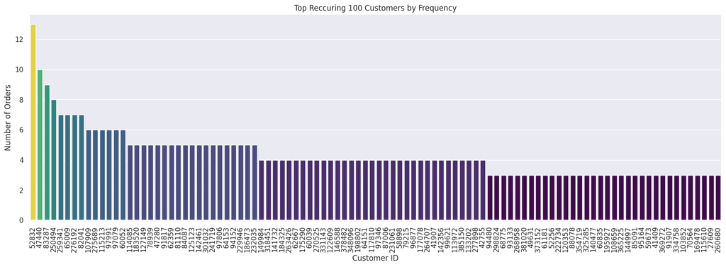

```python
# Get a series of unique customer counts
customer_id_counts = df['customer_id'].value_counts()

# Get total customer count
total_cust_count = len(customer_id_counts)

# Filter customer IDs with counts greater than 1
counts_greater_than_1 = customer_id_counts[df['customer_id'].value_counts() > 1].index

# Get the percentage of customers that ordered more than once
percentage_greater_than_1 = (len(counts_greater_than_1) / total_cust_count) * 100
print(f"Percentage of customers who ordered more than once: {percentage_greater_than_1:.2f}%")

# Get the percentage of customers that ordered once
print(f"Percentage of customers who ordered once: {100 - percentage_greater_than_1:.2f}%")

# number of customers to display
top_n = 100

# Select the top N customers
top_customers = customer_id_counts.head(top_n)

# Plot the horizontal bar chart with percentages
plt.figure(figsize=(20, 6))
barplot = sns.barplot(x=top_customers.index,
                      y=top_customers.values,
                      hue=top_customers.values,
                      order=top_customers.sort_values(ascending=False).index,
                      legend=False,
                      palette='viridis')



plt.title(f'Top Reccuring {top_n} Customers by Frequency')
plt.xlabel('Customer ID')
plt.ylabel('Number of Orders')
plt.xticks(rotation=90);
plt.show();
```

## Restaurant Name

- The most popular restaurant is Shake Shack with 219 orders or 11.54% of all orders.
- The top 5 restaurants are...
  1. Shake Shack
  2. The Meatball Shop
  3. Blue Ribbon Sushi
  4. Blue Ribbon Fried Chicken
  5. Parm
- The bottom 5 restaurants are...
  1. Sushi Choshi
  2. Dos Cominos Soho
  3. La Follia
  4. Philippe Chow
  5. wichcraft

```
Top 5 Restaurants:
Shake Shack                  219
The Meatball Shop            132
Blue Ribbon Sushi            119
Blue Ribbon Fried Chicken     96
Parm                          68
Name: restaurant_name, dtype: int64

Botton 5 Restaurants:
Sushi Choshi        1
Dos Caminos Soho    1
La Follia           1
Philippe Chow       1
'wichcraft          1
Name: restaurant_name, dtype: int64
```

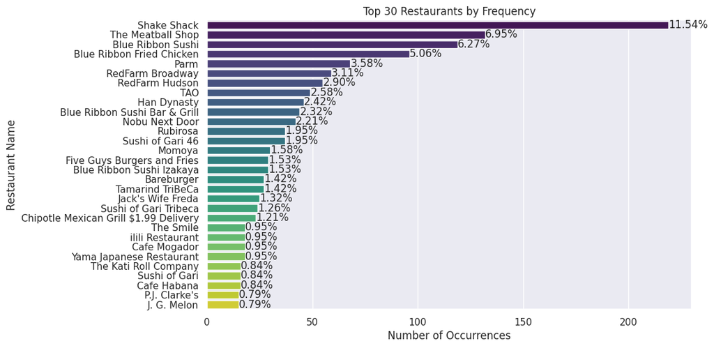

```python
# Get the restaurant frequencies
restaurant_counts = df['restaurant_name'].value_counts()

print("Top 5 Restaurants:")
print(restaurant_counts.head())
print("")
print("Botton 5 Restaurants:")
print(restaurant_counts.tail())
print("")

# Number of restaurants to display
top_n = 30

# Select the top N restaurants
top_restaurants = restaurant_counts.head(top_n)

# Calculate the percentage of occurrences
total_occurrences = len(df['restaurant_name'])
percentage_occurrences = (top_restaurants / total_occurrences) * 100

# Plot the horizontal bar chart with percentages
plt.figure(figsize=(10, 6))
barplot = sns.barplot(x=top_restaurants.values, y=top_restaurants.index,  hue=top_restaurants.index, legend=False, palette='viridis')

# Annotate bars with percentages
for bar, percentage in zip(barplot.patches, percentage_occurrences):
    plt.text(bar.get_width(), bar.get_y() + bar.get_height() / 2, f'{percentage:.2f}%', ha='left', va='center')

plt.title(f'Top {top_n} Restaurants by Frequency')
plt.xlabel('Number of Occurrences')
plt.ylabel('Restaurant Name')
plt.show()
```

## Cuisine Type

- Most popular cuisine type is, American.
- Top 4 cuisine types are...
  1. American
  2. Japanese
  3. Italian
  4. Chinese

```
[]
```

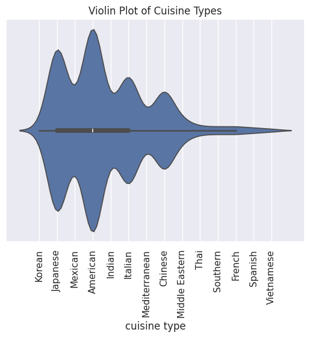

```python
sns.violinplot(data=df, x='cuisine_type');
plt.title('Violin Plot of Cuisine Types')
plt.xlabel('cuisine type')
plt.xticks(rotation=90);
plt.plot()
```

## Cost of the Order

- The orders cost somewhere in range of ~5 - ~35 dollars
- Most orders cost a little above 10 dollars and below 15 dollars
- The cost of the order does not correlate to the number of orders
- It is not a normal distribution around the mean which is ~16.50 dollars

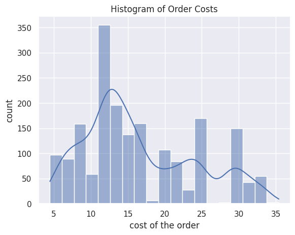

```python
sns.histplot(data=df, x='cost_of_the_order', kde=True);
plt.title('Histogram of Order Costs')
plt.ylabel('count')
plt.xlabel('cost of the order')
plt.plot();
```

## Day of the Week

- Most food is ordered on the weekend.

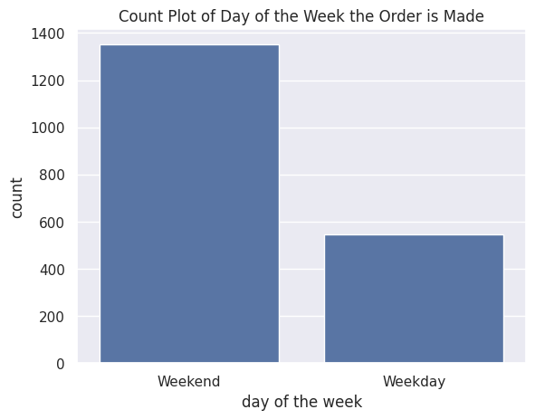

```python
sns.countplot(data=df, x='day_of_the_week');
plt.title('Count Plot of Day of the Week the Order is Made')
plt.ylabel('count')
plt.xlabel('day of the week')
plt.show();
```

## Rating

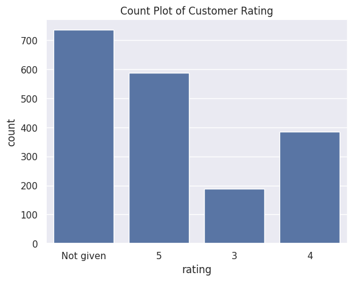

```python
sns.countplot(data=df,x='rating');
plt.title('Count Plot of Customer Rating')
plt.ylabel('count')
plt.xlabel('rating')
plt.show();
```

## Food Preparation Time

- The mean preparation time is around 27 mintues
- There are no outliers
- Food preparation time ranges from 20 to just over 34 minutes
- There is a normal distribution

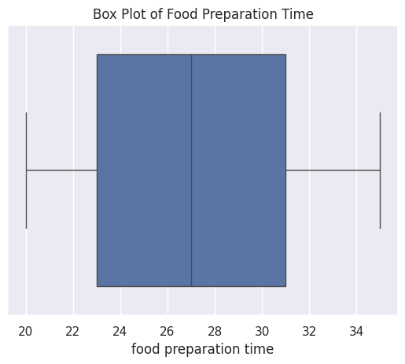

```python
sns.boxplot(data=df, x='food_preparation_time');
plt.title('Box Plot of Food Preparation Time')
plt.xlabel('food preparation time')
plt.show()
```

## Delivery Time

- The mean preparation time is around 25 mintues
- There are no outliers
- Food preparation time ranges from 15 to around 33 mintues
- The distribution is negatively skewed

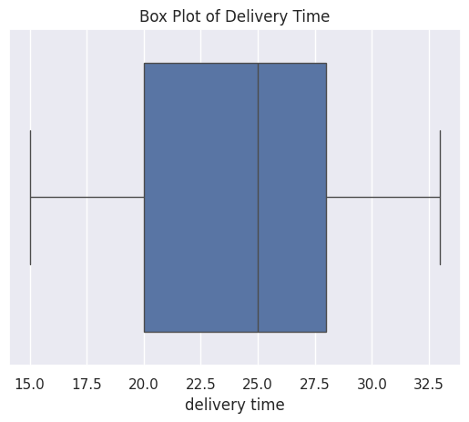

```python
sns.boxplot(data=df, x='delivery_time');
plt.title('Box Plot of Delivery Time')
plt.xlabel('delivery time')
plt.show()
```

### **Question 7**: Which are the top 5 restaurants in terms of the number of orders received? [1 mark]

```python
retaurants = df['restaurant_name'].value_counts() # get the counts of the unique names
retaurants.head(5)
```

```
Shake Shack                  219
The Meatball Shop            132
Blue Ribbon Sushi            119
Blue Ribbon Fried Chicken     96
Parm                          68
Name: restaurant_name, dtype: int64
```

#### Observations:

The top 5 restaurants are...

1. Shake Shack
2. The Meatball Shop
3. Blue Ribbon Sushi
4. Blue Ribbon Fried Chicken
5. Parm

### **Question 8**: Which is the most popular cuisine on weekends? [1 mark]

```
[]
```

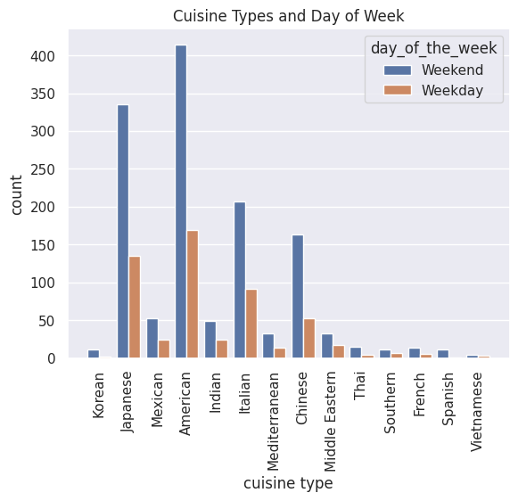

```python
# create count plot for cuisine type with a hue of the day of week
sns.countplot(data=df, x='cuisine_type',hue='day_of_the_week');
plt.title('Cuisine Types and Day of Week')
plt.xlabel('cuisine type')
plt.xticks(rotation=90);
plt.plot()
```

#### Observations: The most popular cuisine on the weekends is American.

### **Question 9**: What percentage of the orders cost more than 20 dollars? [2 marks]

```python
# Filter order costs greater than 20 dollars
cost_more_than_20 = df.loc[df['cost_of_the_order'] > 20]

# Get the percentage of orders greater than 20 dollars
percentage_greater_than_20 = (len(cost_more_than_20) / len(df)) * 100
print(f"{percentage_greater_than_20:.2f}%")
```

```
29.24%
```

#### Observations: 29.24% of orders cost more than 20 dollars

### **Question 10**: What is the mean order delivery time? [1 mark]

```python
df['delivery_time'].mean() #get the mean of delivery time
```

```
24.161749209694417
```

#### Observations: The mean order delivery time is 24.16 minutes

### **Question 11:** The company has decided to give 20% discount vouchers to the top 3 most frequent customers. Find the IDs of these customers and the number of orders they placed. [1 mark]

```python
customers = df['customer_id'].value_counts() # get the counts of the unique ids
customers.head(3)
```

```
52832    13
47440    10
83287     9
Name: customer_id, dtype: int64
```

#### Observations:

The top 3 customers ID's are:

1. 52832 with 13 orders
2. 47440 with 10 orders
3. 83287 with 9 orders

### **Question 12**: Perform a multivariate analysis to explore relationships between the important variables in the dataset. (It is a good idea to explore relations between numerical variables as well as relations between numerical and categorical variables) [10 marks]

## Heatmap that Displays Correlations

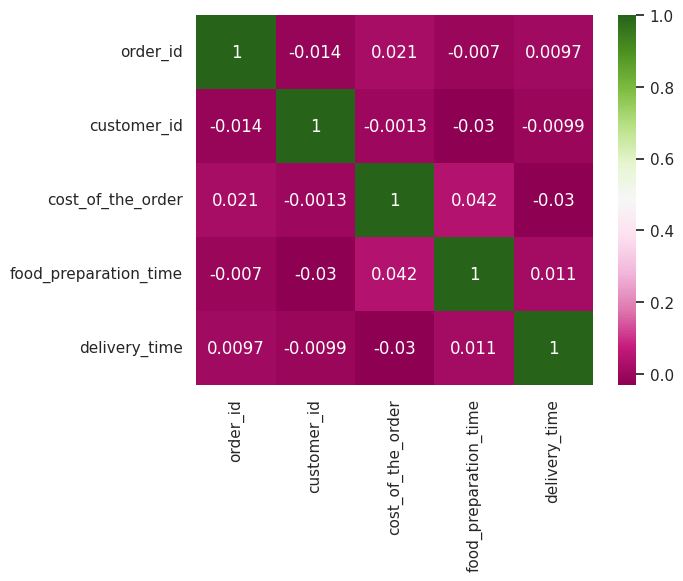

```python
sns.heatmap(data=df.corr(numeric_only=True), annot=True, cmap='PiYG');
```

## Total Cost of Orders for each Cuisine on Weekday vs Weekend

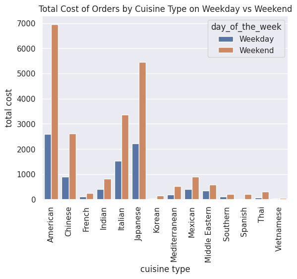

```python
grouped_cusine_type_and_day = df.groupby(['cuisine_type','day_of_the_week']) # group cuisine_type and day_of_the_week
order_cost_sum = grouped_cusine_type_and_day['cost_of_the_order'].sum().reset_index() # get the sum of all the orders' costs

# Plot the results
sns.barplot(x='cuisine_type', y='cost_of_the_order', hue='day_of_the_week', data=order_cost_sum)
plt.title('Total Cost of Orders by Cuisine Type on Weekday vs Weekend')
plt.xlabel('cuisine type')
plt.ylabel('total cost')
plt.xticks(rotation=90);
plt.show()
```

## Cost of Orders for each Cuisine Type

- The most expensive dish is Mediterranean
- The least expensive dish is Japanese
- Most of the dishes are sold at the lower range of cost between 5 and 17 dollars

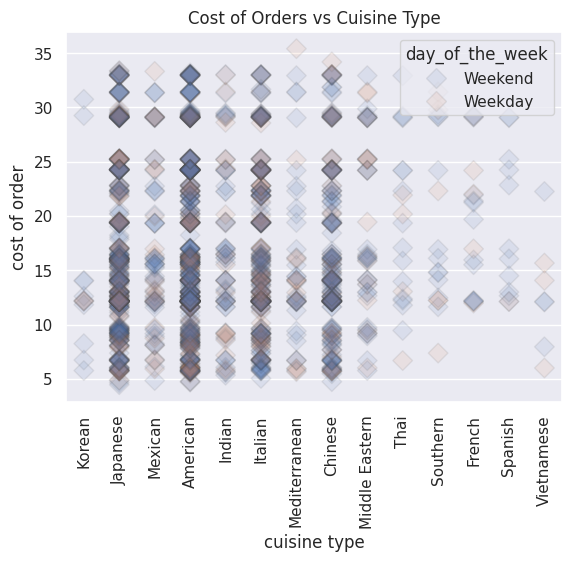

```python
sns.stripplot(data=df,
              x='cuisine_type',
              y='cost_of_the_order',
              hue='day_of_the_week',
              s=10,
              marker="D",
              linewidth=1,
              alpha=.1,
              jitter=False)

plt.title('Cost of Orders vs Cuisine Type')
plt.xlabel('cuisine type')
plt.ylabel('cost of order')
plt.xticks(rotation=90);
plt.show()
```

## Rating vs Delivery Time

- Rating and delivery time does not have an obvious correlation.
- But it is interesting that as delivery time increased the rating went down to a 3. But a rating of 4 is the shortes delivery time. So maybe the 4s are 4s because the the food not the service.

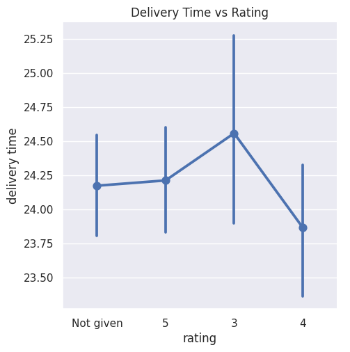

```python
sns.catplot(data=df, x='rating', y='delivery_time',kind='point');
plt.title('Delivery Time vs Rating')
plt.xlabel('rating')
plt.ylabel('delivery time')
plt.show()
```

## Rating vs Food Preparation Time

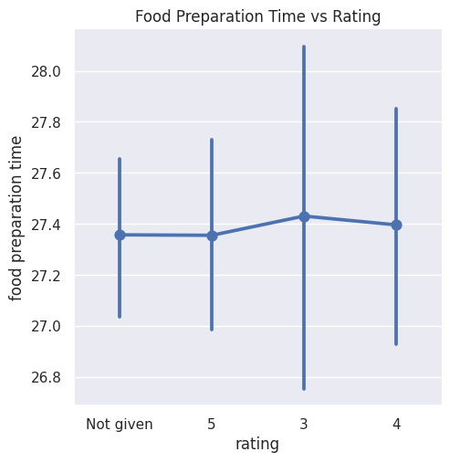

```python
sns.catplot(data=df, x='rating', y='food_preparation_time',kind='point');
plt.title('Food Preparation Time vs Rating')
plt.xlabel('rating')
plt.ylabel('food preparation time')
plt.show()
```

## Cost vs Food Preparation Time

```
Correlation Matrix:
                       cost_of_the_order  food_preparation_time
cost_of_the_order               1.000000               0.041527
food_preparation_time           0.041527               1.000000
```

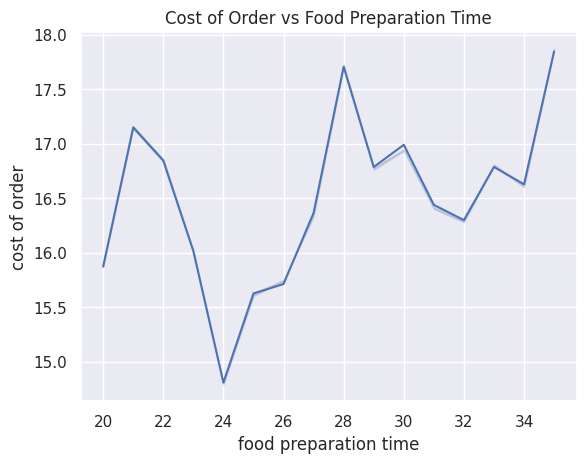

```python
# Calculate the correlation matrix
correlation_matrix = df[['cost_of_the_order', 'food_preparation_time']].corr(numeric_only=True)

# Display the correlation matrix
print("Correlation Matrix: ")
print(correlation_matrix)

sns.lineplot(data=df, y='cost_of_the_order', x='food_preparation_time', errorbar=('ci',True));
plt.title('Cost of Order vs Food Preparation Time')
plt.xlabel('food preparation time')
plt.ylabel('cost of order')
plt.show()
```

## Delivery Time on Weekends vs Weekdays

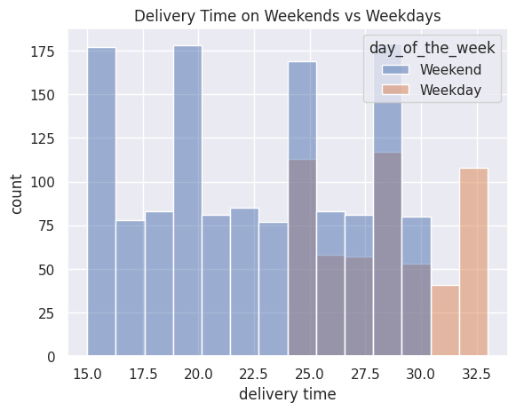

```python
sns.histplot(data = df , x = 'delivery_time' , hue = 'day_of_the_week')
plt.title('Delivery Time on Weekends vs Weekdays')
plt.xlabel('delivery time')
plt.ylabel('count')
plt.show()
```

### **Question 13:** The company wants to provide a promotional offer in the advertisement of the restaurants. The condition to get the offer is that the restaurants must have a rating count of more than 50 and the average rating should be greater than 4. Find the restaurants fulfilling the criteria to get the promotional offer. [3 marks]

```python
# Remove 'not given' ratings
orders_with_ratings = df[df['rating'] != 'Not given']

# Get a series of unique restaurant counts
restaurants = orders_with_ratings['restaurant_name'].value_counts()

# Get restaurants with more than 50 ratings
more_than_50_ratings = restaurants[restaurants > 50]

# Filter the DataFrame to include only retaurants with more than 50 ratings
filtered_df = orders_with_ratings[orders_with_ratings['restaurant_name'].isin(more_than_50_ratings.index)]

# Get the Mean of the ratings per restaurant
average_rating_by_restaurant = filtered_df.groupby('restaurant_name')['rating'].mean()

# print highly rated restaurants
average_rating_by_restaurant[average_rating_by_restaurant > 4]
```

[output not shown]

#### Observations: The restaurants that qualify for the promotion are

1. Blue Ribbon Fried Chicken
2. Blue Ribbon Sushi
3. Shake Shack
4. The Meatball Shop

### **Question 14:** The company charges the restaurant 25% on the orders having cost greater than 20 dollars and 15% on the orders having cost greater than 5 dollars. Find the net revenue generated by the company across all orders. [3 marks]

```
Max: 2875.92, Min: 4.86, Mean: 141.28
```

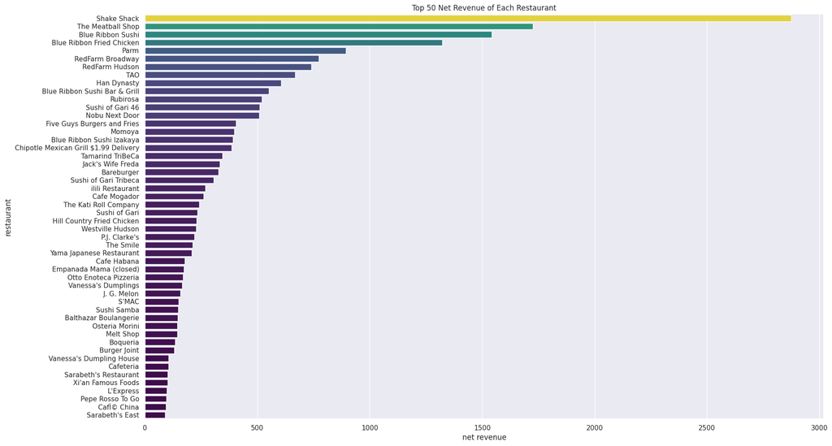

```
                restaurant_name  total_cost  surcharge  net_revenue
96                 Market Table        6.79     1.0185         5.77
164                     Wa Jeal        6.74     1.0110         5.73
39       Cipriani Le Specialita        5.92     0.8880         5.03
17   Big Wong Restaurant _¤¾Ñ¼        5.92     0.8880         5.03
76                  Hunan Manor        5.72     0.8580         4.86
```

```python
# calculate the 25% on orders > 20 and add charge to df
# calculate the 15% on orders > 5 and add charge to df
# zero charge for orders 5 or less and add charge to df
df['surcharge'] = df['cost_of_the_order'].apply(lambda x: 0 if (x <= 5) else (0.15 * x if (x > 5) & (x <= 20) else 0.25 * x))

surcharge_series = df.groupby('restaurant_name')['surcharge'].sum()

# --- group the restaurants the sum up the cost of the orders per restaurant --
cost_series = df.groupby('restaurant_name')['cost_of_the_order'].sum() # get a series with restaurant names and the sum of the cost of orders
cost_df = cost_series.reset_index() # convert the series to a dataframe
cost_df = cost_df.rename(columns={'cost_of_the_order':'total_cost'}) # rename the cost sum column

# merge the surcharge sums
cost_df = pd.merge(cost_df, surcharge_series, left_on='restaurant_name', right_index=True, suffixes=('', '_surcharge'))

# calculate the net revenue for each restaurant
cost_df['net_revenue'] = (cost_df['total_cost'] - cost_df['surcharge']).round(2)

# sorting the net revenue values in descending order
cost_df.sort_values(by='net_revenue',ascending=False,inplace=True)

print(f"Max: {cost_df['net_revenue'].max()}, Min: {cost_df['net_revenue'].min()}, Mean: {cost_df['net_revenue'].mean():.2f}")

# Number of restaurants to display
top_n = 50

# Select the top N restaurants
top_restaurants = cost_df.head(top_n)

# plotting the net revenue
plt.figure(figsize=(20, 12))
barplot = sns.barplot(data=top_restaurants, y='restaurant_name', x='net_revenue',  hue='net_revenue', legend=False, palette='viridis')
plt.title(f'Top {top_n} Net Revenue of Each Restaurant')
plt.xlabel('net revenue')
plt.ylabel('restaurant')
plt.show()

print("")
print(cost_df.tail())
```

### **Question 15:** The company wants to analyze the total time required to deliver the food. What percentage of orders take more than 60 minutes to get delivered from the time the order is placed? (The food has to be prepared and then delivered.) [2 marks]

```
Pecentage of 60 minutes: 10.54%
```

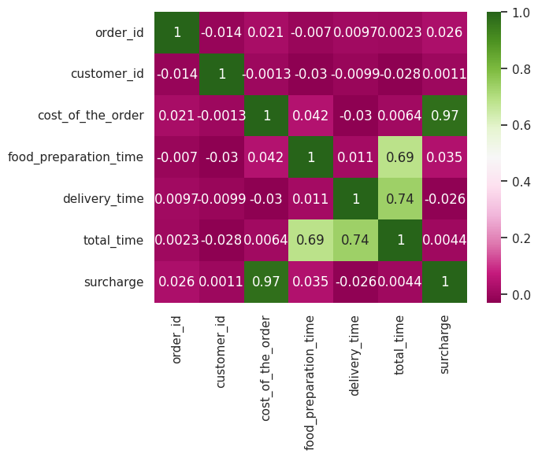

```python
# Caculate the total time an order take from prep to delivery
df['total_time'] = df['food_preparation_time'] + df['delivery_time']

# Moving the total_time column near the other time coloumns
col = df.pop('total_time')
df.insert(9, col.name, col)

# the threshold in minutes the company is showing interest in
threshold_val = 60

# the number of orders that surpass the threshold
count_over_threshold = df.loc[df['total_time'] > threshold_val]['total_time'].count()

#get total_time counts
total_times = df['total_time'].count()

# percentage of total times over 60
percentage_over_threshold = round((count_over_threshold / total_times) * 100, 2)

print(f"Pecentage of 60 minutes: {percentage_over_threshold}%")

sns.heatmap(data=df.corr(numeric_only=True), annot=True, cmap='PiYG');
```

#### Observations: 10.54% of orders take more than 60 minutes.

### **Question 16:** The company wants to analyze the delivery time of the orders on weekdays and weekends. How does the mean delivery time vary during weekdays and weekends? [2 marks]

```python
df.head()
weekend_mean = df.loc[df['day_of_the_week'] == 'Weekend']['delivery_time'].mean()
weekday_mean = df.loc[df['day_of_the_week'] == 'Weekday']['delivery_time'].mean()
print(f"Weekend Mean: {weekend_mean:.2f} min, Weekday Mean: {weekday_mean:.2f} min")
```

```
Weekend Mean: 22.47 min, Weekday Mean: 28.34 min
```

### Recommendations:

- Provide incentives that encourage the customer to rate their order.
- Provide more American, Japanese, Italian, and Chinese cuisine type restaurants.
- Figure out why delivery times increase on the weekdays.
- Provide incentives that encourage customers to order again.
- Make sure restuarants know that meals in the range of \$10 - \$15 dollars with quick food prep time are the most popular.